# 祭祀圈與樣方分析

地理四 何震瑋 b10208003

```r
library(sf)
library(dplyr)
library(showtext)

showtext_auto()
font_add("Heiti TC", "/System/Library/Fonts/STHeiti Medium.ttc")

temples <- st_read("Tempcycle_twd97.shp", quiet = TRUE)
mazu <- temples %>%
  filter(主祭神祇 == "媽祖")
gyps <- temples %>%
  filter(主祭神祇 == "觀音菩薩")
```

### 題目一：祭祀圈中心選址分析

**Q1: 若所有信眾皆從所屬祭祀圈的中心廟宇出發，哪一間媽祖廟作為折返點可最小化總直線距離？**

假設每一間廟的信眾人數相同，讓所有人路走路總距離最短。我們要對所有信仰媽祖的廟宇計算距離矩陣，計算一間廟到所有其他廟的距離總和，找出最小總距離的那一間廟。

```r
dist_matrix <- st_distance(mazu) #兩兩直線距離
total_dists <- apply(dist_matrix, 1, sum) #一間廟到所有其他廟的距離總和
min_index <- which.min(total_dists)
optimal_mazu <- mazu[min_index, ]


cat("🏮 最佳遶境匯流折返點：\n",
    "主神：", optimal_mazu$主祭神祇, "\n",
    "廟名：", optimal_mazu$NAME, "\n" ,
    "地點：", optimal_mazu$FULLNAME)
```

```
🏮 最佳遶境匯流折返點：
 主神： 媽祖
 廟名： 泰寧宮
 地點： 嘉義縣大林鎮
```

**Q2: 若主辦單位決定改成另外搭設遶境大會中心，作為匯流折返點，同樣欲使所有信眾的起終直線距離總和最小化，其中心設置的位置應於何處？**

```r
mean_center <- st_centroid(st_union(mazu))

towns <- st_read("Popn_TWN2.shp", options = "ENCODING=BIG5", quiet = TRUE) %>%
  st_transform(crs = st_crs(mean_center))

mean_center_town <- towns[st_contains(towns, mean_center, sparse = FALSE), ]
cat("📍 建議設置地點：", mean_center_town$TOWN, "\n")
```

```
📍 建議設置地點： 竹山鎮
```

#### Median Center

當目標是最小化總路徑長度、總成本移動距離。所有點位中，能使總直線距離總和最小化的點位，即為Median Center。

#### Mean Center

所有點位的 X 座標與 Y 座標的**算術平均值**所構成的點。當所有點位具有相同權重，且研究目的是最小化總體直線距離平方和時。

### 題目二：南部地區信仰的空間群聚特性

**Q3: 比較南部地區中，主祭神祇為「媽祖」與「觀音菩薩」之寺廟的空間群聚特性。**

將研究區域劃分成20km*20km網格，在每個格網中計算點的出現次數，統計所有格網的出現分布，若出現次數的變異程度遠高於隨機分布，即代表存在「空間群聚」現象

```r
south_counties <- c("嘉義縣", "嘉義市", "台南市", "高雄市", "屏東縣")
mazu_south <- mazu %>%
  filter(COUNTYNAME %in% south_counties)
gyps_south <- gyps %>%
  filter(COUNTYNAME %in% south_counties)

#建立分析格網，計算每個格子內的點數
mazu_grid <- st_make_grid(mazu_south, cellsize = 20000, what = "polygons") %>% st_sf()
mazu_count <- st_contains(mazu_grid, mazu_south) %>% lengths()

gyps_grid <- st_make_grid(gyps_south, cellsize = 20000, what = "polygons") %>% st_sf()
gyps_count <- st_contains(gyps_grid, gyps_south) %>% lengths()
```

```r
# VMR 與統計檢定
mazu_k <- length(mazu_count)
gyps_k <- length(gyps_count)

mazu_vmr <- var(mazu_count)/mean(mazu_count)
gyps_vmr <- var(gyps_count)/mean(gyps_count)

mazu_vmr_se <- sqrt(2 / (mazu_k - 1))
gyps_vmr_se <- sqrt(2 / (gyps_k - 1))

mazu_vmr_t <- (mazu_vmr - 1) / mazu_vmr_se
gyps_vmr_t <- (gyps_vmr - 1) / gyps_vmr_se

mazu_vmr_p <- 2 * pt(mazu_vmr_t, df = mazu_k - 1, lower.tail = mazu_vmr_t < 0)
gyps_vmr_p <- 2 * pt(gyps_vmr_t, df = gyps_k - 1, lower.tail = gyps_vmr_t < 0)
```

#### VMR的概念

`VMR = 樣方內點數的變異數 / 樣方內點數的平均值`

VMR 是衡量點位分布的集中或分散程度的統計指標，用來判斷點模式是否符合 Complete Spatial Randomness（CSR，完全空間隨機分布）。

VMR < 1 ：均勻（Regular） VMR ≈ 1 ：隨機分布 VMR > 1 ：群聚（Clustered）

設定顯著水準 𝛼=0.05  
H0：點分布為隨機分布(𝑠2=𝜆,𝑉𝑀𝑅=1)  
H1：點分布非隨機分布(𝑠2≠𝜆,𝑉𝑀𝑅≠1)

```r
# 顯示檢定結果
cat("媽祖廟 VMR:", round(mazu_vmr, 3), ", p-value:", mazu_vmr_p, "\n")
```

```
媽祖廟 VMR: 13.954 , p-value: 2.36116e-35
```

```r
cat("觀音廟 VMR:", round(gyps_vmr, 3), ", p-value:", gyps_vmr_p, "\n")
```

```
觀音廟 VMR: 2.144 , p-value: 0.003910036
```

[output not shown]

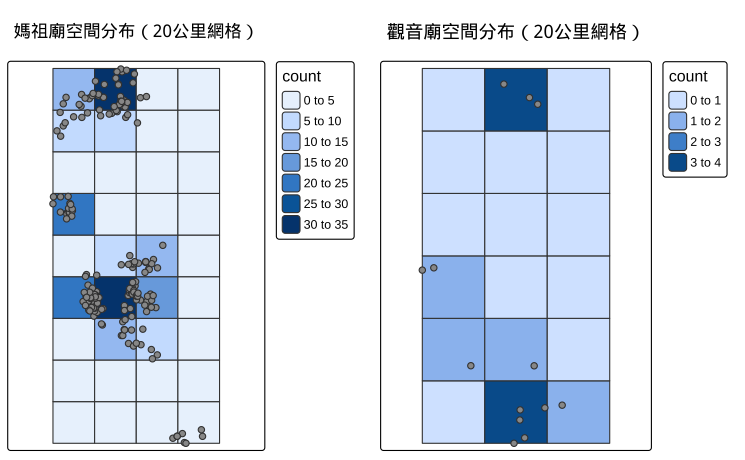

```r
library(tmap)
component.autoscale = FALSE
mazu_grid$count <- mazu_count
map_mazu <- qtm(mazu_grid, fill = "count", title = "媽祖廟空間分布（20公里網格）") +
  qtm(mazu_south, size = 0.4)

gyps_grid$count <- gyps_count
map_gyps <- qtm(gyps_grid, fill = "count", title = "觀音廟空間分布（20公里網格）") +
  qtm(gyps_south, size = 0.4)

tmap_arrange(map_mazu, map_gyps, ncol = 2)
```

根據樣方分析結果：  
媽祖廟 VMR = 13.954，p-value < 0.001 觀音廟 VMR = 2.144，p-value = 0.0039  
因此，兩種寺廟的空間分布皆呈現顯著群聚現象。而媽祖廟的群聚程度遠高於觀音廟，顯示其在南部具有更明顯的地方集中特徵。媽祖信仰在空間上呈現較強的「聚落型」與「歷史集中」分布模式，可能與媽祖信仰的區域傳播、祭祀活動與文化地景緊密相關。

**Q4: 討論樣方網格尺度對群聚分析的影響**

比較 20km × 20km 與 50km × 50km 樣方下，媽祖廟空間分布的群聚統計特性，並討論格網尺度對檢定結果的影響。

```r
mazu_grid_50 <- st_make_grid(mazu_south, cellsize = 50000) %>% st_sf()
count_50 <- st_contains(mazu_grid_50, mazu_south) %>% lengths()

k_50 <- length(count_50)
vmr_50 <- var(count_50) / mean(count_50)
vmr_se_50 <- sqrt(2 / (k_50 - 1))
vmr_t_50 <- (vmr_50 - 1) / vmr_se_50
p_50 <- 2 * pt(vmr_t_50, df = k_50 - 1, lower.tail = vmr_t_50 < 0)
```

```r
# 顯示檢定結果
cat("媽祖廟 20公里樣方 VMR:", round(mazu_vmr, 3), ", p-value:", mazu_vmr_p, "\n")
```

```
媽祖廟 20公里樣方 VMR: 13.954 , p-value: 2.36116e-35
```

```r
cat("媽祖廟 50公里樣方 VMR:", round(vmr_50, 3), ", p-value:", p_50, "\n")
```

```
媽祖廟 50公里樣方 VMR: 51.984 , p-value: 3.668034e-12
```

[output not shown]

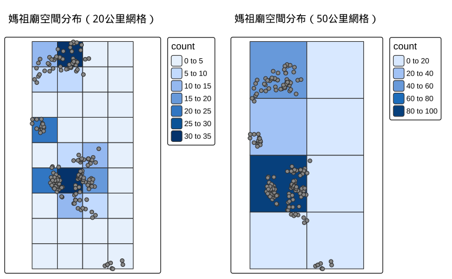

```r
mazu_grid_50$count <- count_50
map_mazu_50 <- qtm(mazu_grid_50, fill = "count", title = "媽祖廟空間分布（50公里網格）") +
  qtm(mazu_south, size = 0.4)

tmap_arrange(map_mazu, map_mazu_50, ncol = 2)
```

雖然兩者的 p-value 都遠小於 0.05，顯示皆為顯著群聚分布，但我們觀察到：  
20km 樣方下的 VMR = 13.954，表現出強烈的局部聚集現象。 50km 樣方下的 VMR = 51.984，顯示高度集中於少數樣方。  
這提醒我們：較小的網格尺度能揭露區域內更細緻的分布差異，適合用於觀察「聚落尺度」的信仰集中。較大的樣方則容易顯示整體性的大型集聚，例如某些都市或港口的宗教中心，但如果網格太大，部分細緻的聚集特性可能被稀釋或模糊。

在媽祖信仰的空間分布分析中，無論是 20km 或 50km 格網皆顯示顯著群聚，但格網大小會改變 VMR 統計數值與視覺判讀的尺度。空間尺度應依照研究目的彈性調整，或搭配多尺度分析以輔助解釋。